# Ejercico evaluable - Redes Sociales

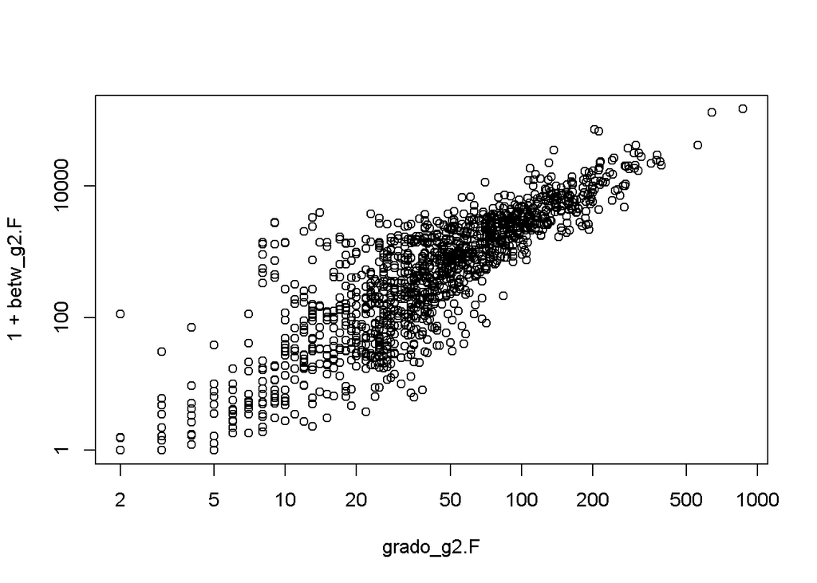

```r
plot(x = grado_g2.F, y = 1+betw_g2.F, log = "xy") # NOTA: Usamos 1 + betweenness para evitar log(0)
```

```r
# Calculamos la correlación entre ambas medidas:
cor(betw_g2.F, grado_g2.F)
```

```
## [1] 0.7718077
```

```r
cor(log(betw_g2.F[betw_g2.F != 0]), log(grado_g2.F[betw_g2.F != 0]))
```

```
## [1] 0.837212
```

En la componente fuertemente conexa principal (g2.F), se ve más claramente la correlación, mucho mayor (0,77), entre el grado y la betweenness de sus 1.300 nodos. De hecho, como se ve en los gráficos, la correlación es mucho más clara (0,84) entre los logaritmos de ambas medidas (excluyendo en este caso 3 nodos que tienen betweenness nula).

```r
# Ahora miramos la componente principal (débilmente) conexa (g2 = g2.D):
betw_g2 <- betweenness(g2, directed = FALSE)
grado_g2 <- degree(g2, mode = "all")

print(paste0('Hay ', sum(betw_g2==0), ' nodos (el ', round(100 * sum(betw_g2==0) / vcount(g2), 0), '%) con betweenness nula'))
```

```
## [1] "Hay 2471 nodos (el 35%) con betweenness nula"
```

```r
print('Distribución de los grados de estos nodos con betweenness nula:')
```

```
## [1] "Distribución de los grados de estos nodos con betweenness nula:"
```

```r
print(summary(grado_g2[betw_g2==0]))
```

```
##    Min. 1st Qu.  Median    Mean 3rd Qu.    Max.
##   1.000   1.000   1.000   1.108   1.000   4.000
```

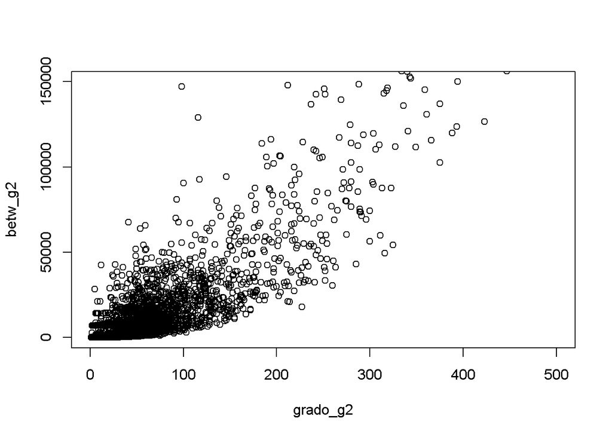

```r
plot(x = grado_g2, y = betw_g2, xlim = c(0, 500), ylim = c(0, 150000))
```

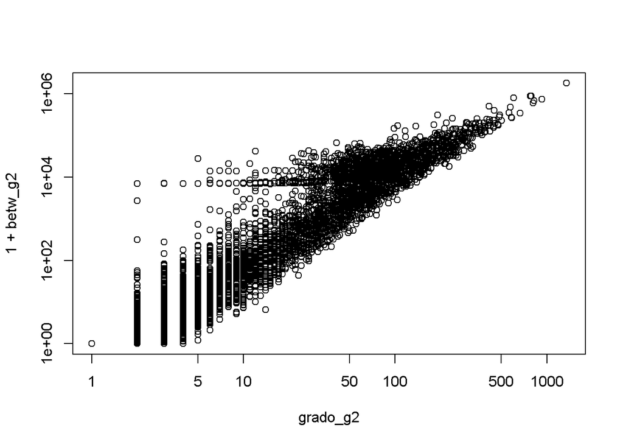

```r
plot(x = grado_g2, y = 1+betw_g2, log = "xy") # NOTA: Usamos 1 + betweenness para evitar log(0)
```

```r
# Calculamos la correlación entre ambas medidas:
cor(betw_g2, grado_g2)
```

```
## [1] 0.7973101
```

```r
cor(log(betw_g2[betw_g2 != 0]), log(grado_g2[betw_g2 != 0]))
```

```
## [1] 0.9206708
```

En la componente débilmente conexa principal (g2.D) usamos la betweenness sin dirección (ya que con dirección se parece mucho al grafo original). Tambíen hay una fuerte la correlación, mucho mayor (0,80), entre el grado y la betweenness de sus 7.066 nodos. De hecho, como se ve en los gráficos, la correlación es mucho más clara (0,92) entre los logaritmos de ambas medidas (excluyendo en este caso 2.471 nodos que tienen betweenness nula).

### Visualización de grafos

Utiliza el layout llamado layout.lgl para visualizar la red y colorea los nodos dependiendo de  
i) si eran candidatos y ganaron la votación (verde)  
ii) fueron candidatos y no ganaron la votación (rojos)  
iii) pinta los mentores azul y  
iv) los que solamente votan en amarillo.

Para detectar los candidatos, mentores (nominators) y el resultado de la votación, utiliza el fichero metadata.txt adjunto.

```r
#CHUNK 10: visualiza la red con las condiciones dadas.
meta_dat <- read.csv('metadata.txt', sep = ';', stringsAsFactors = FALSE)#, nrows = 100)
str(meta_dat)
```

```
## 'data.frame':    2794 obs. of  4 variables:
##  $ candidate: chr  "cjcurrie" "zoney" "gerald_farinas" "andrevan" ...
##  $ nominator: chr  "andyl" "neutrality" "neutrality" "node_ue" ...
##  $ deadline : chr  "2004-09-21 01:15:53" "2004-09-21 20:49:47" "2004-09-18 09:54:32" "2006-11-02 22:01:34" ...
##  $ result   : int  1 1 1 1 1 0 1 0 0 0 ...
```

```r
print(paste0('los resultados posibles de la votación son: (', paste0(
  unique(meta_dat$result)
    , collapse = ','), ')'))
```

```
## [1] "los resultados posibles de la votación son: (1,0)"
```

```r
# meta_dat$candidate
# meta_dat$nominator
# meta_dat$deadline
# meta_dat$result
print('Verificamos fechas:')
```

```
## [1] "Verificamos fechas:"
```

```r
md.year <- substr(meta_dat$deadline, start = 1, stop = 4)
md.mon <- substr(meta_dat$deadline, start = 6, stop = 7)
md.day <- substr(meta_dat$deadline, start = 9, stop = 10)
sort(unique(md.day)) # *** Ok. ***
```

```
##  [1] "01" "02" "03" "04" "05" "06" "07" "08" "09" "10" "11" "12" "13" "14"
## [15] "15" "16" "17" "18" "19" "20" "21" "22" "23" "24" "25" "26" "27" "28"
## [29] "29" "30" "31"
```

```r
sort(unique(md.mon)) # *** Ok. ***
```

```
##  [1] "01" "02" "03" "04" "05" "06" "07" "08" "09" "10" "11" "12"
```

```r
sort(unique(md.year)) # *** Ok. ***
```

```
## [1] "2004" "2005" "2006" "2007" "2008"
```

```r
# Convertimos fecha a POSIXct (valor numérico):
meta_dat$deadline <- as.POSIXct(meta_dat$deadline, format = "%Y-%m-%d %H:%M:%S", tz = "GMT")

print(paste('Hay', length(unique(paste(meta_dat$candidate))), 'candidatos distintos y', nrow(meta_dat), 'votaciones.'))
```

```
## [1] "Hay 2391 candidatos distintos y 2794 votaciones."
```

```r
print('NOTA: Nos quedamos con la última votación de cada candidato y usaremos ese resultado.')
```

```
## [1] "NOTA: Nos quedamos con la última votación de cada candidato y usaremos ese resultado."
```

```r
# Obtenemos la última fecha de cada candidato:
meta2_dat <- meta_dat %>% group_by(candidato=candidate) %>% summarize(fecha=max(deadline))
# Construimos el resto del data.frame con los datos de cada candidato:
meta2_dat <- merge(x = meta2_dat, y = meta_dat, all.x = TRUE, all.y = FALSE
      , by.x = c("candidato", "fecha"), by.y = c("candidate", "deadline"))
```

Creamos fichero con gráfico de cada red (la red inicial completa y las dos sub-redes creadas a partir de las componentes débil y fuertemente conexas principales)

```r
##########################################
# Creamos fichero con gráfico de cada red:
##########################################

grf$nombre_fichero <- "practica_redes_jjtz_full.png"
g2.D$nombre_fichero <- "practica_redes_jjtz_debil.png"
g2.F$nombre_fichero <- "practica_redes_jjtz_fuerte.png"
# Eliminamos gráficos para volver a generarlos (entre 5 y 10 minutos cada uno!!!)
# NOTA: Comentar estas líneas para no volver a generarlos (layout+plot)
try(if(file.exists(grf$nombre_fichero)) file.remove(grf$nombre_fichero), silent=TRUE)
```

```
## [1] TRUE
```

```r
try(if(file.exists(g2.D$nombre_fichero)) file.remove(g2.D$nombre_fichero), silent=TRUE)
```

```
## [1] TRUE
```

```r
try(if(file.exists(g2.F$nombre_fichero)) file.remove(g2.F$nombre_fichero), silent=TRUE)
```

```
## [1] TRUE
```

```r
for(grf_plot in list(grf, g2.D, g2.F))
{
  print(paste('Visualizando red:', grf_plot$name, '-', grf_plot$nombre_fichero))
  # Construimos un nuevo data.frame con estos filtrando solo los candidatos de grf_plot:
  df_vg <- data.frame(candidato=V(grf_plot)$name)
  V_meta2_dat <- merge(x = df_vg, y = meta2_dat, all.x = TRUE, all.y = FALSE
        , by = "candidato")
  # Y lo ponemos en el mismo orden que V(grf_plot)
  V_meta2_dat <- meta2_dat[match(x = V(grf_plot)$name, table = meta2_dat$candidato),]

  head(V(grf_plot))
  head(V_meta2_dat)

  # Finalmente, guardamos esos datos como atributos en el grafo (en los vértices):
  V(grf_plot)$es_candidato <- (V(grf_plot)$name %in% meta_dat$candidate)
  V(grf_plot)$es_mentor <- (V(grf_plot)$name %in% meta_dat$nominator)
  V(grf_plot)$resultado       <- ifelse(is.na(V_meta2_dat$result), -1, V_meta2_dat$result)
  # # Estos dos no hacen falta:
  # V(grf_plot)$mentor          <- V_meta2_dat$nominator
  # V(grf_plot)$fecha_resultado <- V_meta2_dat$fecha

  print(paste(sum(V(grf_plot)$es_candidato), 'candidatos'))
  print(paste(sum(V(grf_plot)$es_mentor), 'mentores'))
  print(paste(nrow(df_vg) - sum(V(grf_plot)$es_candidato | V(grf_plot)$es_mentor), 'solo votantes'))

  print(paste(sum(V(grf_plot)$resultado == 1),'candidatos ganaron la (última) votación'))
  print(paste(sum(V(grf_plot)$resultado == 0),'candidatos perdieron la (última) votación'))
  print(paste(sum(V(grf_plot)$resultado == -1),'no candidatos'))

  summary(grf_plot)

  # Finalmente, pintamos el grafo (grf_plot):
  # i) si eran candidatos y ganaron la votación (verde) <br>
  # ii) fueron candidatos y no ganaron la votación (rojos) <br>
  # iii) pinta los mentores azul y <br>
  # iv) los que solamente votan en amarillo.
  rojo <- rgb(1,0,0,0.5)
  verde <- rgb(0,1,0,0.5)
  azul <- rgb(0,0,1,0.5)
  amarillo <- rgb(1,1,0,0.5)
  # Colores para los vértices:
  v_color <- ifelse(V(grf_plot)$es_candidato & V(grf_plot)$resultado == 1, verde,
                    ifelse(V(grf_plot)$es_candidato & V(grf_plot)$resultado == 0, rojo,
                           ifelse(V(grf_plot)$es_mentor == 1, azul,
                                  amarillo)))
  table(v_color)
  # Colores para los enlaces (verde es positivo y rojo negativo):
  e_color <- ifelse(E(grf_plot)$voto == 1, verde, rojo)
  table(e_color)

  if(!file.exists(grf_plot$nombre_fichero))
  {
    v_cnt <- vcount(grf_plot)
    mi_tiempo <- system.time({
      ly <<- layout_with_lgl(grf_plot
                      , maxiter = 150
                      , maxdelta = v_cnt
                      , area = v_cnt^2
                      , coolexp = 1.5
                      , repulserad = v_cnt^3
                      , cellsize = sqrt(v_cnt)
                      , root = NULL)
    })
    print(paste0("Tiempo layout(): ", round(mi_tiempo[3],1), " segundos."))
    if(grf_plot$name == grf$name)
    {
      # NOTA: En el caso del grafo completo, reducimos la dispersión en el layout porque la mayor
      #       parte de los enlaces se concentran demasiado en el centro:
      # p.ej. alejamos los puntos del centro proporcionalmente al inverso
      #       de la distancia inicial al centro (al punto medio):
      x2 <- ly[,1]
      y2 <- ly[,2]
      x0 <- mean(x2)
      y0 <- mean(y2)
      max.d <- sqrt(max((x2 - x0)^2 + (y2 - y0)^2))
      K.d <- max.d / ((x2 - x0)^2 + (y2 - y0)^2)
      x2 <- K.d * (x2 - x0) + x0
      y2 <- K.d * (y2 - y0) + y0
      ly[,1] <- x2
      ly[,2] <- y2
    }
    mi_tiempo <- system.time({
      png(grf_plot$nombre_fichero, width=800, height=800)
      # x11()
      plot.igraph(grf_plot
                  , layout = ly
                  , edge.width = 0.5, edge.arrow.size = 0.6, edge.arrow.width = 0.8
                  , edge.color = e_color
                  , vertex.label = '' # Quitamos labels
                  , vertex.size = 3 #, vertex.size = degree(grf_plot)
                  , vertex.color = v_color
                  , main = grf_plot$name
      )
      dev.off()
    })
    print(paste0("Tiempo plot(): ", round(mi_tiempo[3]/60,1), " minutos."))
  } # Fin de if(!file.exists(grf_plot$nombre_fichero))
  print(paste('Ok.', '-', grf_plot$nombre_fichero))

} # for()
```

```
## [1] "Visualizando red: Wiki-elecciones - practica_redes_jjtz_full.png"
## [1] "2381 candidatos"
## [1] "380 mentores"
## [1] "4658 solo votantes"
## [1] "1193 candidatos ganaron la (última) votación"
## [1] "1188 candidatos perdieron la (última) votación"
## [1] "4734 no candidatos"
## IGRAPH DN-- 7115 106994 -- Wiki-elecciones
## + attr: name (g/c), nombre_fichero (g/c), name (v/c), es_candidato
## | (v/l), es_mentor (v/l), resultado (v/n), voto (e/n), timestamp
## | (e/n)
## [1] "Tiempo layout(): 59 segundos."
```

```
## [1] "Tiempo plot(): 9.8 minutos."
## [1] "Ok. - practica_redes_jjtz_full.png"
## [1] "Visualizando red: Wiki-elecciones (Componente débilmente conexa) - practica_redes_jjtz_debil.png"
## [1] "2358 candidatos"
## [1] "380 mentores"
## [1] "4632 solo votantes"
## [1] "1193 candidatos ganaron la (última) votación"
## [1] "1165 candidatos perdieron la (última) votación"
## [1] "4708 no candidatos"
## IGRAPH DN-- 7066 106968 -- Wiki-elecciones (Componente débilmente conexa)
## + attr: name (g/c), nombre_fichero (g/c), name (v/c), es_candidato
## | (v/l), es_mentor (v/l), resultado (v/n), voto (e/n), timestamp
## | (e/n)
## [1] "Tiempo layout(): 39.3 segundos."
```

```
## [1] "Tiempo plot(): 9.9 minutos."
## [1] "Ok. - practica_redes_jjtz_debil.png"
## [1] "Visualizando red: Wiki-elecciones (Componente fuertemente conexa) - practica_redes_jjtz_fuerte.png"
## [1] "1300 candidatos"
## [1] "246 mentores"
## [1] "0 solo votantes"
## [1] "842 candidatos ganaron la (última) votación"
## [1] "458 candidatos perdieron la (última) votación"
## [1] "0 no candidatos"
## IGRAPH DN-- 1300 40966 -- Wiki-elecciones (Componente fuertemente conexa)
## + attr: name (g/c), nombre_fichero (g/c), name (v/c), es_candidato
## | (v/l), es_mentor (v/l), resultado (v/n), voto (e/n), timestamp
## | (e/n)
## [1] "Tiempo layout(): 1.8 segundos."
```

```
## [1] "Tiempo plot(): 3.8 minutos."
## [1] "Ok. - practica_redes_jjtz_fuerte.png"
```

Gráficos de cada red:

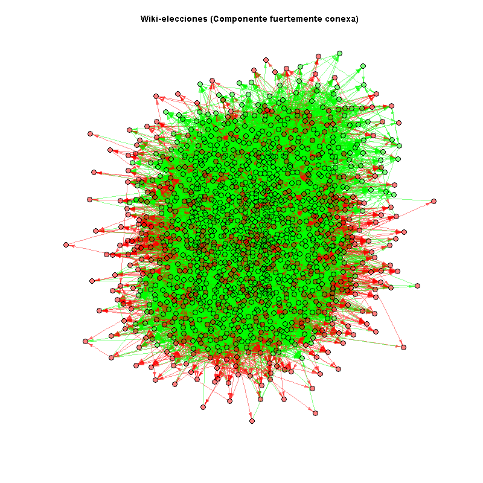

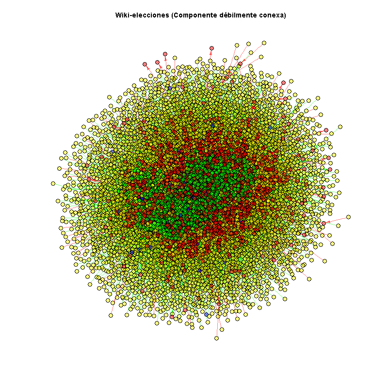

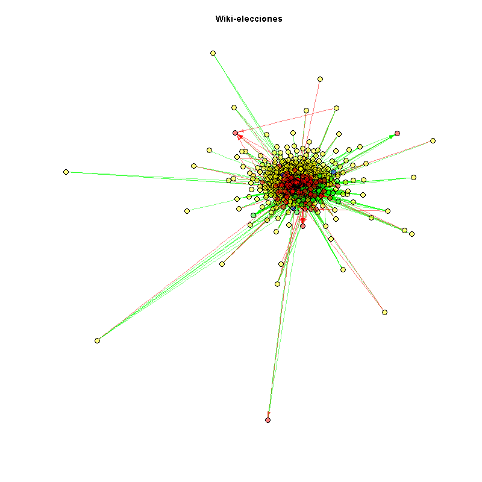

### Validando hipótesis sociales

En este ejercicio, tienes que idear un método para demostrar:

- “El amigo de mi amigo, es mi amigo”
- “El amigo de mi enemigo, es mi enemigo”
- “El enemigo de mi amigo, es mi enemigo”

Considera las votaciones del dataset original y ten en cuenta el timestamp para llevar a cabo el análisis.

```r
#CHUNK 11: código para evaluar estas frases

# Relación A es amigo de B == A vota 1 a B o bien B vota 1 a A
# Relación A es enemigo de B == A vota -1 a B o bien B vota -1 a A
# Las 3 frases se traducen como AB * BC == AC, con fecha(AC) > max(fecha(AB),fecha(BC))
# "El amigo de mi amigo, es mi amigo" (+1 * +1 == +1)
# "El amigo de mi enemigo, es mi enemigo" (+1 * -1 == -1)
# "El enemigo de mi amigo, es mi enemigo" (-1 * +1 == -1)

# Se trata de buscar cliques de 3 vértices (triángulos conectados),
# sin dirección pero con el peso (el voto)
# En cada clique, ordenamos por fechas de voto (A<B<C) y obtenemos las posibles combinaciones
# para (AB, BC, CA) como votos: +++ ++- +-+ +-- -++ -+- --+ ---
# 1.- Tiene que haber muchas más de tipo +++ (amigo-amigo=>amigo) que de tipo ++- (amigo=>enemigo)
# 2.- Tiene que haber muchas más de tipo +-- (amigo-enemigo=>enemigo) que de tipo +-+
# 3.- Tiene que haber muchas más de tipo -+- (enemigo-amigo=>enemigo) que de tipo -++

gr_11 <- as.undirected(grf, mode = "each") # mode = "each" para no perder los atributos (voto y timestamp)
gr_11$name <- paste(gr_11$name, '- Amistades')
summary(gr_11)
```

```
## IGRAPH UN-- 7115 106994 -- Wiki-elecciones - Amistades
## + attr: name (g/c), nombre_fichero (g/c), name (v/c), voto (e/n),
## | timestamp (e/n)
```

```r
# Reducimos el grafo para ir más rápido (me quedo solo con los enlaces ordenados de los triángulos):
tr <- triangles(graph = gr_11)
secu <- rbind(seq(1, length(tr)-2, 3), seq(2, length(tr)-1, 3),
              seq(2, length(tr)-1, 3), seq(3, length(tr)  , 3),
              seq(1, length(tr)-2, 3), seq(3, length(tr)  , 3))
# E(gr_11, tr[secu[,NN]]) son los 3 edges del triángulo NN (AB,BC,CA)
ABC <- E(graph = gr_11, P = tr[as.vector(secu)])
# E(gr_11, tr[secu]]) son los edges de los triángulos (12,23,13,45,56,46,etc.)

fechas <- ABC$timestamp
votos <- ABC$voto

# Variables para guardar los resultados:
# NOTA: Vectores, data.frames y data.tables son muy lentos. Usamos listas.
# rels = data.table::data.table(j = c("V1","V2","V3","L1","L2","L3","F1","F2","F3"))
votos.ord <- list()
# Variable para guardar los tiempos:
mi_tiempo_total <- vector()
lng <- length(ABC) / 3
mi_tiempo <- system.time({
  for(NN in seq(1, lng, 1))
  {
    # ABC <- E(gr_tr, tr[secu[,NN]])
    pos <- (3 * NN - 2):(3 * NN)
    vot <- votos[pos]
    if(all(vot == 1) | all(vot == -1))
    {
      # No hace falta ordenar por fecha si son los 3 iguales:
      votos.ord[[NN]] <- vot
    }
    else
    {
      # Ordenamos por fecha:
      fech <- fechas[pos]
      votos.ord[[NN]] <- vot[order(fech)]
    }
    # rels <- rbindlist(rels, use.names = TRUE, fill = TRUE,
    #                   c(votos[order(fechas)], ABC[order(fechas)], fechas[order(fechas)]))
    if (NN %% 10000 == 0)
    {
      print(paste0(round(100 * NN / lng, 2), '%'))
    }
  }
})
```

```
## [1] "1.64%"
## [1] "3.29%"
## [1] "4.93%"
## [1] "6.57%"
## [1] "8.22%"
## [1] "9.86%"
## [1] "11.51%"
## [1] "13.15%"
## [1] "14.79%"
## [1] "16.44%"
## [1] "18.08%"
## [1] "19.72%"
## [1] "21.37%"
## [1] "23.01%"
## [1] "24.66%"
```

[output cut: 45 more lines]

```r
# mi_tiempo_total <- rbind(mi_tiempo_total, mi_tiempo[3])
print(paste0("Tiempo: ", round(mi_tiempo[3]/60,1), " minutos."))
```

```
## [1] "Tiempo: 15.2 minutos."
```

```r
# print(paste0("Tiempo Total acumulado: ", round(sum(mi_tiempo_total)/60, 3), " minutos."))
# print(paste0("Tiempo Total estimado: ", (lng/NN) * round(sum(mi_tiempo_total)/60, 3), " minutos."))

# colnames(rels) <- c("V1","V2","V3","L1","L2","L3","F1","F2","F3")
# rels$F1 <-as.POSIXct(rels$F1, origin = "1970-01-01 00:00.00 UTC")
# rels$F2 <-as.POSIXct(rels$F2, origin = "1970-01-01 00:00.00 UTC")
# rels$F3 <-as.POSIXct(rels$F3, origin = "1970-01-01 00:00.00 UTC")
# head(rels)
# num_amigos <- sum(rels$V1 == 1 & rels$V2 == 1 & rels$V3 == 1) # 1 1 1
# num_NO_amigos <- sum(rels$V1 == 1 & rels$V2 == 1 & rels$V3 == -1) # 1 1 -1
# num_enemigos <- sum(rels$V1 * rels$V2 == -1 & rels$V3 == -1) # 1 -1 -1 / -1 1 -1
# num_NO_enemigos <- sum(rels$V1 * rels$V2 == -1 & rels$V3 == 1) # 1 -1 1 / -1 1 1

num_amigos      <- sum(sapply(X = votos.ord, FUN = function(x){all(x == c(+1,+1,+1));}))
num_NO_amigos   <- sum(sapply(X = votos.ord, FUN = function(x){all(x == c(+1,+1,-1));}))
num_enemigos    <- sum(sapply(X = votos.ord, FUN = function(x){all(x == c(+1,-1,-1));}))
num_NO_enemigos <- sum(sapply(X = votos.ord, FUN = function(x){all(x == c(+1,-1,+1));}))
num_enemigs2    <- sum(sapply(X = votos.ord, FUN = function(x){all(x == c(-1,+1,-1));}))
num_NO_enemigs2 <- sum(sapply(X = votos.ord, FUN = function(x){all(x == c(-1,+1,+1));}))
num_amigs2      <- sum(sapply(X = votos.ord, FUN = function(x){all(x == c(-1,-1,+1));}))
num_NO_amigs2   <- sum(sapply(X = votos.ord, FUN = function(x){all(x == c(-1,-1,-1));}))

num_amigos
```

```
## [1] 417666
```

```r
num_enemigos
```

```
## [1] 21363
```

```r
num_enemigs2
```

```
## [1] 12063
```

```r
num_amigs2
```

```
## [1] 19748
```

```r
P_amigos_amigos     <- num_amigos   / (num_amigos   + num_NO_amigos)
P_amigos_enemigos   <- num_enemigos / (num_enemigos + num_NO_enemigos)
P_enemigos_amigos   <- num_enemigs2 / (num_enemigs2 + num_NO_enemigs2)
P_enemigos_enemigos <- num_amigs2   / (num_amigs2   + num_NO_amigs2)

# Calculamos también los porcentajes sobre el total de triángulos:
P_amigos_tot      <- (num_amigos      + num_amigs2)      / length(votos.ord)
P_NO_amigos_tot   <- (num_NO_amigos   + num_NO_amigs2)   / length(votos.ord)
P_enemigos_tot    <- (num_enemigos    + num_enemigs2)    / length(votos.ord)
P_NO_enemigos_tot <- (num_NO_enemigos + num_NO_enemigs2) / length(votos.ord)

# Comprobamos:
# length(votos.ord) == num_amigos + num_NO_amigos + num_enemigos + num_NO_enemigos + num_enemigs2 + num_NO_enemigs2 + num_amigs2 + num_NO_amigs2

# Resultados:
print(data.frame(P_amigos_amigos, P_NO_amigos_amigos=1-P_amigos_amigos))
```

```
##   P_amigos_amigos P_NO_amigos_amigos
## 1       0.8963963          0.1036037
```

```r
print(data.frame(P_enemigos_enemigos, P_NO_enemigos_enemigos=1-P_enemigos_enemigos))
```

```
##   P_enemigos_enemigos P_NO_enemigos_enemigos
## 1           0.7291659              0.2708341
```

```r
# Ok!

print(data.frame(P_amigos_enemigos, P_NO_amigos_enemigos=1-P_amigos_enemigos))
```

```
##   P_amigos_enemigos P_NO_amigos_enemigos
## 1         0.3480676            0.6519324
```

```r
print(data.frame(P_enemigos_amigos, P_NO_enemigos_amigos=1-P_enemigos_amigos))
```

```
##   P_enemigos_amigos P_NO_enemigos_amigos
## 1         0.2234261            0.7765739
```

```r
# !!!

print(data.frame(P_amigos_tot, P_NO_amigos_tot,
                 P_enemigos_tot, P_NO_enemigos_tot))
```

```
##   P_amigos_tot P_NO_amigos_tot P_enemigos_tot P_NO_enemigos_tot
## 1    0.7189709      0.09140205     0.05494182         0.1346852
```